# Market analysis for the pharmaceutical retail industry

Ignacio Orueta

15/01/2025

**ChatGPT/AI disclosure statement:**

I used Copilot as a coding assistant for troubleshooting syntax coding problems, in the cleaning process to figure out the best Regex expressions and in adding options for my plots.

## 1. Introduction

In today’s competitive retail markets, the location of businesses is crucial for meeting companies’ annual growth targets. The objective of this project is to retrieve useful data to elaborate a market analysis to assist a pharmacy company on selecting the best locations in London for open new stores. In order to choose these places, the analysis provides three key insights for a retail business to succeed. These are: 1) The Potential demand that they will face, 2) The competition intensity of the surrounding areas, and 3) The average rent costs of the neighbourhood. The data is retrieved from multiple sources, such as the Transport for London (TfL) website, Google Maps, and Rightmove, the UK’s largest online real estate property portal.

## 2. Retrieving secondary data

Considering secondary data, I retrieved the names of all London’s boroughs, allowing me to create a list for searching pharmacies stores in each borough. This was made by scraping Wikipedia’s webpage: https://en.wikipedia.org/wiki/List_of_London_boroughs.

Note: I change the position of sections 2 and 3. This allow me to run my code correctly.

## 3. Retrieving primary data

### 1. Potential demand data

First, I collect data on the number of entries and exits of each Transport for London’s station. This accounts for the potential demand of clients in the areas nearby each station, based on foot traffic. Tube entries and exits are a good estimtaion of foot traffic in London, especially in central areas, where there is a large transient population and where there is a high tax on other ways of transport, such as cars.

To achieve this, I downloaded the data directly from the TfL website: https://crowding.data.tfl.gov.uk

### 2. Competition data

Then, I scrape Google Maps to look for all pharmacies in each London Borough. This step includes collecting their names, addresses, georeferences and review scores. This is useful to assess the level of competition within each area of the city.

### 3. Rent cost data

Finally, I collect data on the monthly rent cost per square foot for available commercial spaces suitable for retail businesses in each area from Rightmove. This is essential for understanding the rental market, their prices, and the availability of spaces near each station. Here, I collect information from each station on a radius of 1/4 mile, to look for places that are within a 5 minute walk from each station. This approach is important because the project’s aim is to analyze foot traffic demand near train stations. Thus, expanding the radius would result in inaccurate estimations of potential demand, which I obtained from the TfL dataset.

## 4. Transformations

The different data sources collected through the scraping process needed to be cleaned and transformed in order to be analysed.

## 5. Using the data

The retrieved data is useful for several purposes. First, it allows to estimate a significant share of the potential demand of pharmacy stores in locations near stations. Assuming that foot demand is the main demand that retail stores face in the streets, and that a significant part of the foot traffic comes from and to tube stations, the entries and exits in stations are a good proxy of potential demand for retail stores.

Finally, the retrieved data from RightMove considers only retail spaces that are available for rent within a radius 1/4 miles each station, which is approximately a 5-minute walk. This restriction helps target locations with high foot traffic, crucial for retail stores, especially pharmacies. In these businesses, clients often prioritize proximity over brand loyalty, seeking the nearest store for convenience.

## 6. Output

The data retrieved above allows to analyse the market in several useful ways. Here, I present three charts that illustrate the project’s value for market analysis.

### 1. Potential demand data

The chart below shows the annual entry and exits from each geolocated station. Immediately, we can distinguish which stations receive more passengers, which are commonly in the city center.

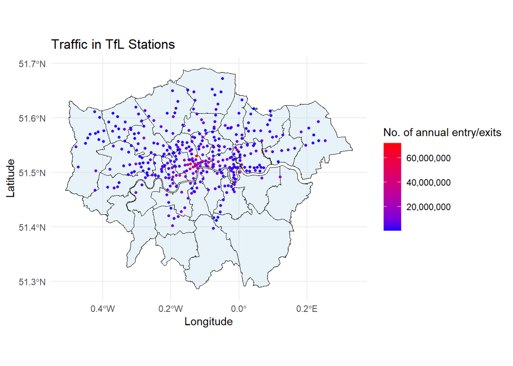

### 2. Competition data

The next chart shows the locations of pharmacy retail businesses across London’s boroughs. Here, it is clear that some boroughs have a higher concentration of pharmacy stores than others.

Note: This is a sample of scraped pharmacies and don’t represent the whole universe of open pharmacies.

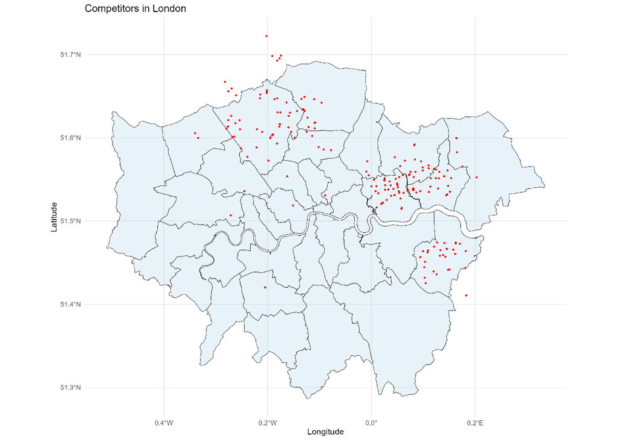

Note: I couldn’t finish the scraping before uploading my results since RStudio rebooted during the night.

### 3. Rent costs data

Finally, here you can see the available places within a 1/4 radius from a station. I also calculated their respective rent cost per square foot. As expected, the city center is the most expensive place for rent commercial properties.

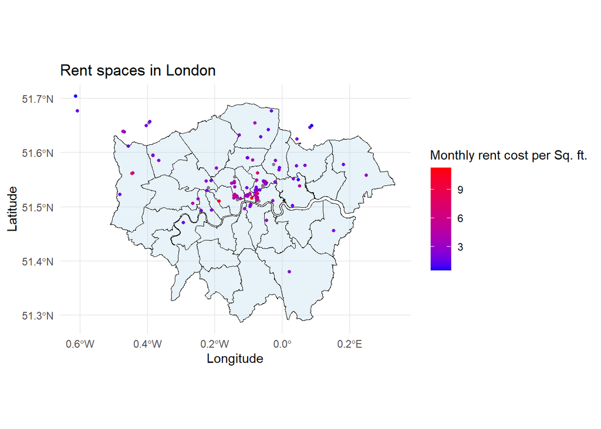

Note: This is a sample of scraped properties and don’t represent the whole universe of properties available.